# Estadística Fundamental para Ciencias de la Salud

Pruebas de Hipótesis

Giovany Babativa-Márquez, PhD

jgbabativam@unal.edu.co

# INFERENCIA ESTADÍSTICA

## ¿Qué es la inferencia estadística?

La **inferencia estadística** es el proceso de obtener conclusiones sobre una **población** a partir de una **muestra**.

Dos grandes problemas:

1. **Estimación**: ¿cuánto vale el parámetro?
   - Estimación puntual: $\bar{x}$, $\hat{p}$, $s^2_x$
   - Estimación por intervalo: IC al 90%, 95%, 99%
2. **Contraste de hipótesis**: ¿es compatible el parámetro con un valor particular?
   - ¿La media de HbA1c<sup>1</sup> de los pacientes es distinta de 7%?
   - ¿El tratamiento A es mejor que el B?
[^1]: hemoglobina glicosilada o glicada, es un análisis de sangre que indica el nivel promedio de glucosa (azúcar) en tu cuerpo durante los últimos 2 a 3 meses

## El ciclo inferencial en salud

### Distribución muestral

Si tomamos **todas** las muestras posibles de tamaño $n$ y calculamos el estadístico $T$ en cada una, obtenemos la **distribución muestral** de $T$.

**Teorema Central del Límite (TCL):**

Si $X_1, X_2, \ldots, X_n \overset{iid}{\sim} (\mu, \sigma^2)$ y $n$ es suficientemente grande:

$$\bar{X} \sim N\!\left(\mu,\; \frac{\sigma^2}{n}\right)$$

El **error estándar** es $SE = \sigma/\sqrt{n}$.

# DISTRIBUCIONES MUESTRALES

## Suma de variables aleatorias normales

Si $X_1, \ldots, X_n \overset{iid}{\sim} N(\mu, \sigma^2)$:

$$\sum_{i=1}^n X_i \sim N(n\mu,\; n\sigma^2)$$

$$\bar{X} = \frac{1}{n}\sum_{i=1}^n X_i \sim N\!\left(\mu,\; \frac{\sigma^2}{n}\right)$$

La variable **estandarizada**:

$$Z = \frac{\bar{X} - \mu}{\sigma/\sqrt{n}} \sim N(0,1)$$

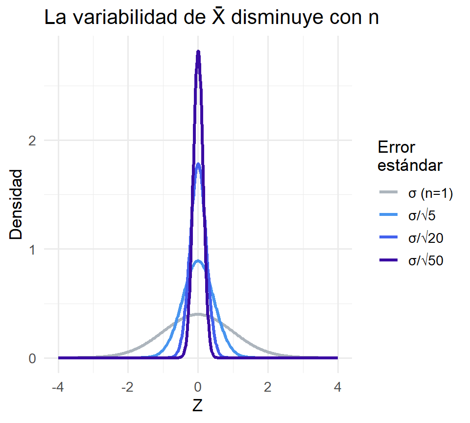

## El estimador: propiedades deseables

Un **estimador** $\hat{\theta}$ de un parámetro $\theta$ es una función de los datos muestrales que busca aproximarse al valor verdadero.

**Propiedades:**

| Propiedad | Significado |
| --- | --- |
| **Insesgado** | $E[\hat\theta] = \theta$ |
| **Consistente** | $\hat\theta \xrightarrow{p} \theta$ cuando $n \to \infty$ |
| **Eficiente** | Varianza mínima |

**Tip**

**En salud:** - $\bar{X}$ es estimador insesgado de $\mu$ (HbA1c promedio) - $\hat{p} = X/n$ es estimador insesgado de $p$ (proporción de hipertensos) - $S^2$ con divisor $n-1$ es insesgado para $\sigma^2$

**Note**

La calidad de un estimador mejora al **aumentar el tamaño de muestra**. El error estándar $SE = s/\sqrt{n}$ cuantifica la precisión.

## Distribución Chi-cuadrado ($\chi^2$)

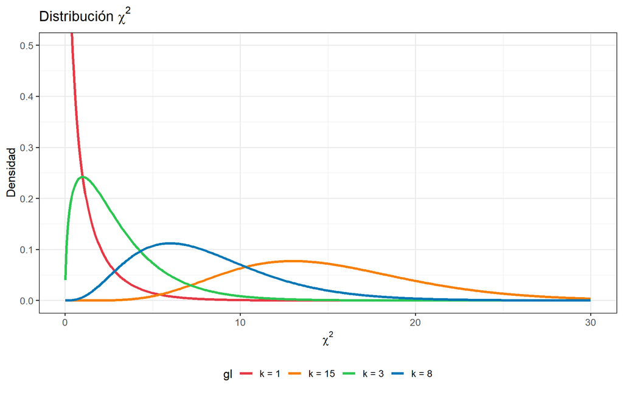

## Distribución Chi-cuadrado ($\chi^2$)

Si $Z_1, \ldots, Z_k \overset{iid}{\sim} N(0,1)$:

$$X^2_k = Z_1^2 + Z_2^2 + \cdots + Z_k^2$$

$$X^2_k \sim \chi^2_{k}$$

**Usos:**

> Prueba de bondad de ajuste

> Prueba de independencia (tablas)

> Inferencia sobre **varianzas**

Solo toma valores mayores que cero; se vuelve más simétrica cuando crece $k$.

## Distribución t de Student

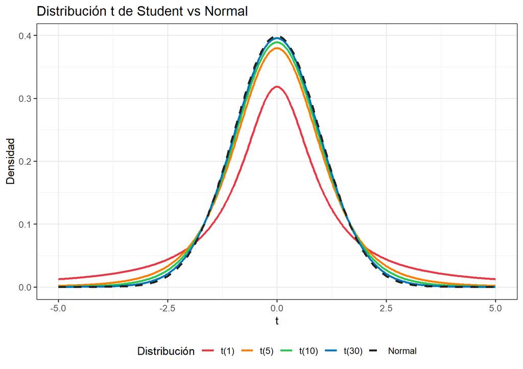

## Distribución t de Student

Si $Z \sim N(0,1)$ y $V \sim \chi^2(k)$ independientes:

$$T = \frac{Z}{\sqrt{V/k}} \sim t(k)$$

En la práctica:

$$T = \frac{\bar{X} - \mu}{S/\sqrt{n}} \sim t(n-1)$$

**Usos:** Inferencia sobre medias cuando $\sigma$ es **desconocida**.

- Más dispersa que $N(0,1)$
- Con $k \to \infty$ converge a $N(0,1)$

## Distribución F de Fisher-Snedecor

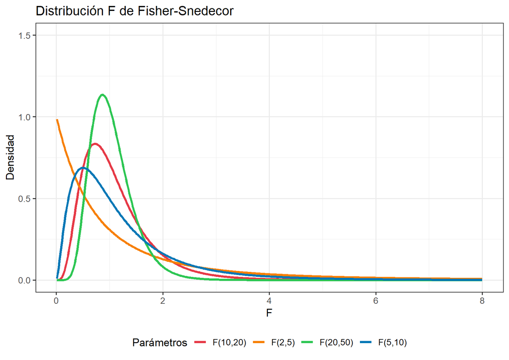

## Distribución F de Fisher-Snedecor

Si $U \sim \chi^2(k_1)$ y $V \sim \chi^2(k_2)$ independientes:

$$F = \frac{U/k_1}{V/k_2} \sim F(k_1, k_2)$$

En la práctica:

$$F = \frac{S_1^2}{S_2^2} \quad \text{(bajo } H_0: \sigma_1^2=\sigma_2^2\text{)}$$

**Usos:**

- Comparar **varianzas** (dos muestras)
- **ANOVA** (comparar varias medias)

Solo toma valores mayores que cero; asimétrica positiva.

# CONTRASTE DE HIPÓTESIS

## Pruebas de hipótesis

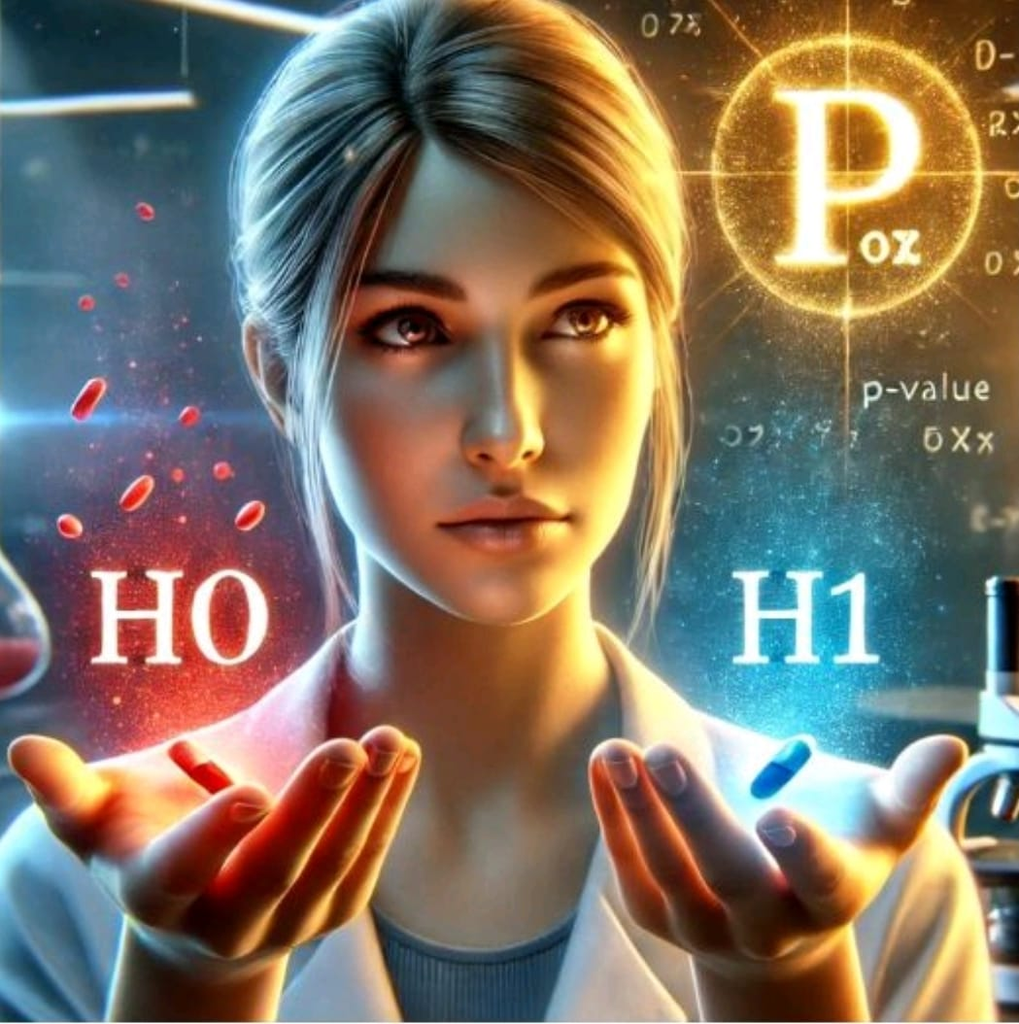

## Estructura general del contraste

Un **contraste de hipótesis** es una regla de decisión estadística que permite, a partir de los datos muestrales, pronunciarse sobre una afirmación sobre un parámetro poblacional.

**Pasos:**

1. Plantear $H_0$ y $H_a$
2. Elegir el nivel de significancia $\alpha$
3. Identificar el estadístico de prueba
4. Calcular el estadístico y el **valor-p**
5. Tomar la decisión: rechazar o no rechazar $H_0$
6. Interpretar en contexto clínico

## Estructura general del contraste

**Note**

**Hipótesis nula** $H_0$: afirmación de partida que supone igualdad, ausencia de efecto o valor de referencia.

**Hipótesis alterna** $H_a$: lo que quiere demostrarse; contiene $\neq$, $>$ o $<$.

| Prueba | $H_a$ | Región de rechazo |
| --- | --- | --- |
| Bilateral | $\theta \neq \theta_0$ | Dos colas |
| Unilateral $>$ | $\theta > \theta_0$ | Cola derecha |
| Unilateral $<$ | $\theta < \theta_0$ | Cola izquierda |

## Tipos de error

|  | **$H_0$ es verdadera** | **$H_0$ es falsa** |
| --- | --- | --- |
| **Rechazar $H_0$** | Error tipo I ($\alpha$) | Decisión correcta ($1-\beta$) |
| **No rechazar $H_0$** | Decisión correcta ($1-\alpha$) | Error tipo II ($\beta$) |

- **$\alpha$** = P(rechazar $H_0$ | $H_0$ verdadera) = **nivel de significancia**
- **$\beta$** = P(no rechazar $H_0$ | $H_0$ falsa)
- **Potencia** = $1 - \beta$ = P(detectar el efecto cuando existe)

**Warning**

**En salud:** - Error tipo I: declarar efectivo un tratamiento ineficaz → daño al paciente - Error tipo II: no detectar un tratamiento efectivo → oportunidad perdida - Los dos errores están en conflicto: reducir $\alpha$ tiende a aumentar $\beta$

## Relación entre $\alpha$, $\beta$ y potencia

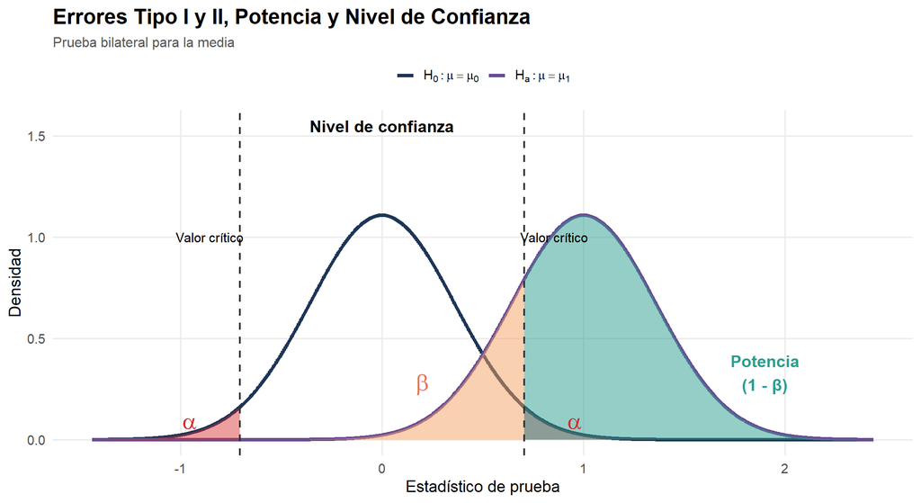

## El valor-p

El **valor-p** es la probabilidad de observar un estadístico de prueba **tan extremo o más extremo** que el calculado, **suponiendo que $H_0$ es verdadera**.

**Regla de decisión:**

- Si $p \leq \alpha$: rechazar $H_0$ → resultado estadísticamente significativo
- Si $p > \alpha$: no rechazar $H_0$ → no hay evidencia suficiente

**Warning**

El valor-p **NO** es:

- La probabilidad de que $H_0$ sea cierta
- La magnitud del efecto clínico
- Una medida de importancia práctica

## Significancia vs relevancia clínica

**Tip**

**Interpretación clínica:**

Un resultado puede ser **estadísticamente significativo** ($p < 0.05$) pero **clínicamente irrelevante** (efecto muy pequeño en muestra grande).

Siempre debe acompañar el valor-p con el **tamaño del efecto** y el **intervalo de confianza**.

**Ejemplo**

Un estudio con 50,000 pacientes encontró que un medicamento redujo el peso corporal en promedio **0.4 kg** respecto al placebo ($p < 0.001$).

Aunque el resultado es altamente significativo estadísticamente, la reducción de 0.4 kg probablemente tiene poca importancia clínica para la mayoría de pacientes.

## Determinación del tamaño de muestra

**Para contrastar una media:**

$$\boxed{n = \frac{(z_{\alpha/2} + z_\beta)^2 \,\sigma^2}{\delta^2}}$$

donde $\delta = |\mu_1 - \mu_0|$ es la diferencia clínicamente relevante.

**Para contrastar una proporción:**

$$\boxed{n = \frac{(z_{\alpha/2} + z_\beta)^2 \,p_0(1-p_0)}{\delta^2}}$$

## Determinación del tamaño de muestra

**Ejemplo:** Queremos detectar una reducción de 5 mmHg en PAS ($\delta=5$), $\sigma=15$, $\alpha=0.05$, potencia $=80\%$.

$$z_{0.025}=1.96, \quad z_{0.20}=0.842$$

$$n = \frac{(1.96+0.842)^2 \times 15^2}{5^2} = \frac{(2.802)^2 \times 225}{25} \approx 71$$

```r
power.t.test(delta=5, sd=15, sig.level=0.05,
             power=0.80, type="one.sample")$n
```

```
[1] 72.58407
```

# PRUEBA $\chi^2$ DE INDEPENDENCIA

## Concepto y estadístico

Evalúa si existe **asociación** entre dos variables categóricas en una tabla de contingencia $r \times c$.

$$\boxed{H_0: \text{Las variables son independientes} \quad vs \quad H_a: \text{existe asociación}}$$

**Frecuencias esperadas** bajo $H_0$:

$$E_{ij} = \frac{n_{i\cdot} \cdot n_{\cdot j}}{n}$$

**Estadístico de prueba:**

$$\chi^2 = \sum_{i}\sum_{j} \frac{(O_{ij} - E_{ij})^2}{E_{ij}} \sim \chi^2_{(r-1)(c-1)}$$

**Condición:** $E_{ij} \geq 5$ en todas las celdas.

## Observaciones

**Tip**

Si alguna $E_{ij} < 5$, se recomienda:

- Prueba exacta de Fisher (tablas $2\times 2$)
- Combinar categorías cuando sea posible clínicamente

**Note**

La prueba $\chi^2$ **no mide la fuerza** de la asociación. Para ello use:

- $V$ de Cramér: $V = \sqrt{\chi^2 / (n \cdot \min(r-1,c-1))}$
- Razón de momios (OR) en tablas $2\times 2$

## Ejemplo: Tabaquismo y EPOC

**Contexto:** 300 pacientes atendidos en una clínica respiratoria. Se registró si el paciente es fumador y si tiene diagnóstico de EPOC.

|  | EPOC (+) | EPOC (−) | Total |
| --- | --- | --- | --- |
| Fumador | 85 | 65 | 150 |
| No fumador | 35 | 115 | 150 |
| **Total** | 120 | 180 | 300 |

**¿Existe una asociación entre tener diagnóstico de EPOC y fumar?**

$E_{11} = \frac{150 \times 120}{300} = 60 \quad E_{12} = \frac{150 \times 180}{300} = 90 \quad E_{21} = 60 \quad E_{22} = 90$

$$\chi^2 = \frac{(85-60)^2}{60}+\frac{(65-90)^2}{90}+\frac{(35-60)^2}{60}+\frac{(115-90)^2}{90}$$

$$= 10.42 + 6.94 + 10.42 + 6.94 = \mathbf{34.72}$$

$gl = (2-1)(2-1) = 1$; $\chi^2_{0.05,1} = 3.841$

Como $34.72 > 3.841$ **→ Se rechaza $H_0$**.

## Código R:

```r
tabla <- matrix(c(85, 65, 35, 115),
                nrow=2, byrow=TRUE,
                dimnames=list(c("Fumador","No fumador"),
                              c("EPOC+","EPOC-")))
chisq.test(tabla)
```

```
    Pearson's Chi-squared test with Yates' continuity correction

data:  tabla
X-squared = 33.347, df = 1, p-value = 7.709e-09
```

La función `chisq.test()` en R aplica automáticamente la **corrección de continuidad de Yates** para tablas $2 \times 2$, esto busca evitar sobreestimar la evidencia estadística en muestras pequeñas.

$$\chi^2_Y = \sum_{i}\sum_{j} \frac{|O_{ij} - E_{ij}| - 0.5)^2}{E_{ij}}$$

## Visualización: mosaico y barras

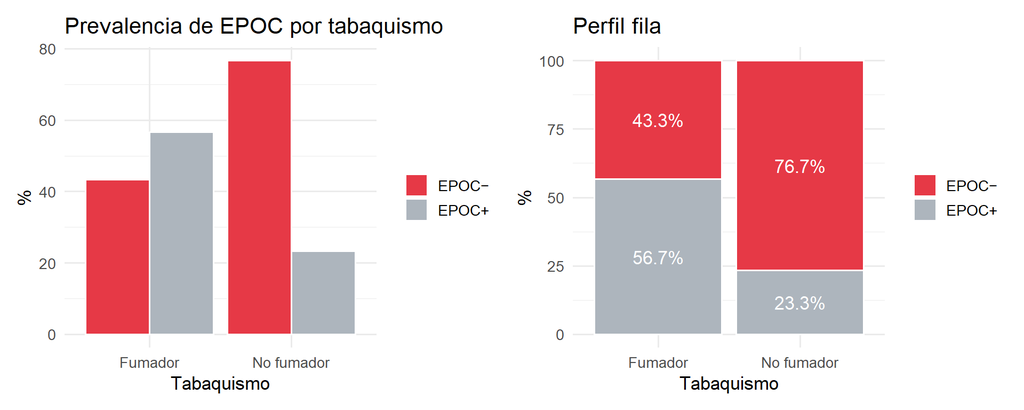

**Tip**

El 56.7% de los fumadores tiene EPOC vs solo el 23.3% de los no fumadores. La razón de momios $OR = (85\times115)/(65\times35) = 4.3$ indica que los fumadores tienen 4.3 veces más probabilidad de tener EPOC.

# PRUEBAS PARA PROPORCIONES

## Prueba para una proporción

Contrasta si la proporción poblacional es igual a un valor $p_0$.

$$H_0: p = p_0 \quad vs \quad H_a: p \neq p_0$$

**Estadístico de prueba:**

$$\boxed{Z = \frac{\hat{p} - p_0}{\sqrt{p_0(1-p_0)/n}}}$$

Bajo $H_0$, $Z \sim N(0,1)$ aproximadamente (requiere $np_0 \geq 5$ y $n(1-p_0) \geq 5$).

**IC al $(1-\alpha)$%:**

$$\hat{p} \pm z_{\alpha/2}\sqrt{\frac{\hat{p}(1-\hat{p})}{n}}$$

## Prueba para una proporción

**Ejemplo:** Una unidad de enfermería reporta 72% de adherencia a la higiene de manos ($p_0 = 0.72$). En una auditoría de 80 registros se observó adherencia en 64 casos ($\hat{p} = 0.80$). ¿Ha mejorado?

$H_0: p = 0.72$ vs $H_a: p > 0.72$

$$Z = \frac{0.80 - 0.72}{\sqrt{0.72 \times 0.28/80}} = \frac{0.08}{0.0502} = 1.595$$

$p\text{-valor} = P(Z > 1.595) = 0.055$

**Conclusión:** Con $\alpha = 0.05$, $p = 0.055 > 0.05$. No se rechaza $H_0$; la evidencia no es suficiente para afirmar que la adherencia mejoró.

## Código de R

```r
# Prueba unilateral: ¿Ha mejorado la adherencia?
prop.test(x = 64, n = 80, p = 0.72,
          alternative = "greater",
          conf.level = 0.95, correct = FALSE)
```

```
    1-sample proportions test without continuity correction

data:  64 out of 80, null probability 0.72
X-squared = 2.5397, df = 1, p-value = 0.05551
alternative hypothesis: true p is greater than 0.72
95 percent confidence interval:
 0.7171766 1.0000000
sample estimates:
  p
0.8
```

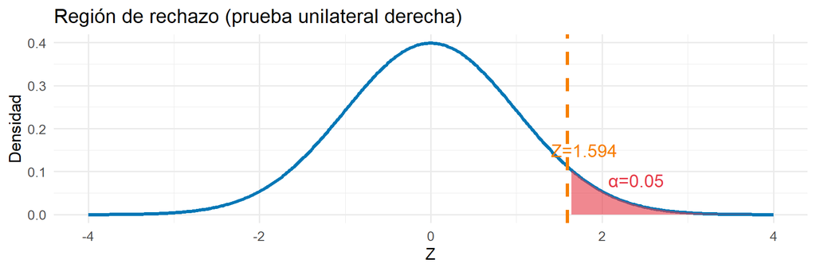

## API de Shiny

[Abrir API](https://antoinesoetewey.shinyapps.io/statistics-201/)

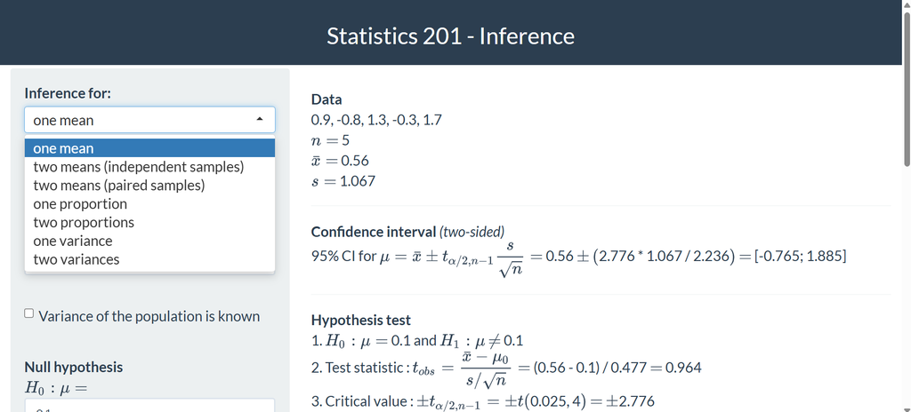

## Prueba para dos proporciones

Compara proporciones de dos grupos independientes.

$$H_0: p_1 = p_2 \quad vs \quad H_a: p_1 \neq p_2$$

**Estadístico de prueba:**

$$\boxed{Z = \frac{\hat{p}_1 - \hat{p}_2}{\sqrt{\hat{p}(1-\hat{p})\left(\frac{1}{n_1}+\frac{1}{n_2}\right)}}}$$

donde $\hat{p} = \frac{x_1+x_2}{n_1+n_2}$ es la proporción combinada.

**IC al $(1-\alpha)$%:**

$$(\hat{p}_1 - \hat{p}_2) \pm z_{\alpha/2} \sqrt{\hat{p}(1-\hat{p})\left(\frac{1}{n_1}+\frac{1}{n_2}\right)}$$

## Prueba para dos proporciones

**Ejemplo clínico:** Tasa de infección nosocomial en dos UCI.

| UCI | Pacientes ($n$) | Infecciones ($x$) | $\hat{p}$ |
| --- | --- | --- | --- |
| A | 80 | 18 | 0.225 |
| B | 75 | 8 | 0.107 |

$\hat{p} = (18+8)/(80+75) = 0.168$

**→ Se rechaza $H_0$. Diferencia significativa.**

## Código R: dos proporciones

```r
prop.test(x = c(18, 8), n = c(80, 75),
          alternative = "two.sided",
          conf.level = 0.95, correct = FALSE)
```

```
    2-sample test for equality of proportions without continuity correction

data:  c(18, 8) out of c(80, 75)
X-squared = 3.8827, df = 1, p-value = 0.04879
alternative hypothesis: two.sided
95 percent confidence interval:
 0.003208078 0.233458588
sample estimates:
   prop 1    prop 2
0.2250000 0.1066667
```

**Tip**

# PRUEBAS PARA MEDIAS

## Prueba t para una media

Contrasta si la media poblacional es igual a un valor $\mu_0$.

$$H_0: \mu = \mu_0 \quad vs \quad H_a: \mu \neq \mu_0$$

**Estadístico de prueba:**

$$\boxed{t = \frac{\bar{x} - \mu_0}{s/\sqrt{n}}} \sim t_{n-1} \text{ bajo } H_0$$

Supuesto: la variable sigue distribución normal (o $n \geq 30$).

**IC al $(1-\alpha)$%:**

$$\bar{x} \pm t_{\alpha/2, n-1} \cdot \frac{s}{\sqrt{n}}$$

## Prueba t para una media

**Ejemplo:** El umbral de buen control glucémico en diabetes tipo 2 es $HbA1c = 7\%$. En 20 pacientes de un programa de rehabilitación se midió: $\bar{x} = 7.8\%$, $s = 1.2\%$.

$H_0: \mu = 7$ vs $H_a: \mu \neq 7$

$$t = \frac{7.8 - 7}{1.2/\sqrt{20}} = \frac{0.8}{0.268} = 2.98$$

$gl = 19$; $t_{0.025, 19} = 2.093$

Como $|t| = 2.98 > 2.093$ **→ Rechazar $H_0$**.

$p = 0.008 < 0.05$. El nivel medio de HbA1c es significativamente mayor que 7%.

## Código R: prueba t una muestra

```r
set.seed(2024)
HbA1c <- c(7.2,8.1,7.5,8.8,7.0,9.1,6.8,8.3,7.9,7.4,
           8.6,7.1,8.9,7.7,8.2,9.0,7.3,8.0,7.6,8.5)
t.test(HbA1c, mu = 7, alternative = "two.sided")
```

```
    One Sample t-test

data:  HbA1c
t = 5.9738, df = 19, p-value = 9.492e-06
alternative hypothesis: true mean is not equal to 7
95 percent confidence interval:
 7.617153 8.282847
sample estimates:
mean of x
     7.95
```

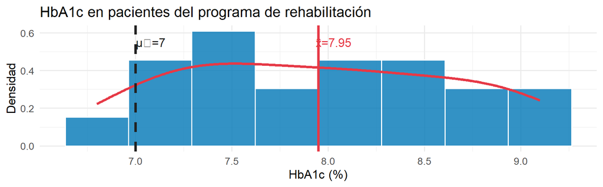

## Prueba t para dos muestras independientes

Compara medias de dos grupos independientes.

$$H_0: \mu_1 = \mu_2 \quad vs \quad H_a: \mu_1 \neq \mu_2$$

**Con varianzas iguales** ($s_p^2$ = varianza pooled):

$$\boxed{t = \frac{\bar{x}_1 - \bar{x}_2}{s_p\sqrt{1/n_1+1/n_2}}}$$

$$s_p^2 = \frac{(n_1-1)s_1^2+(n_2-1)s_2^2}{n_1+n_2-2}$$

$gl = n_1 + n_2 - 2$

**Con varianzas desiguales** (Welch):

$$t_W = \frac{\bar{x}_1 - \bar{x}_2}{\sqrt{s_1^2/n_1+s_2^2/n_2}}$$

## Prueba t para dos muestras independientes

**Ejemplo:** Tiempo de hospitalización (días) en dos grupos de pacientes con neumonía: Grupo A (tratamiento estándar, $n_1=12$): $\bar{x}_1=6.8$, $s_1=1.5$; Grupo B (protocolo nuevo, $n_2=12$): $\bar{x}_2=5.3$, $s_2=1.4$.

$s_p^2 = \frac{11 \times 1.5^2 + 11 \times 1.4^2}{22} = \frac{24.75+21.56}{22} = 2.105$

$$t = \frac{6.8-5.3}{\sqrt{2.105(1/12+1/12)}} = \frac{1.5}{0.593} = 2.53$$

$gl=22$; $t_{0.025,22}=2.074$. **→ Rechazar $H_0$** ($p=0.019$).

## Código R: dos muestras independientes

```r
GrupoA <- c(7.2,6.1,7.8,5.9,6.5,7.0,8.1,6.3,7.5,6.0,7.3,5.8)
GrupoB <- c(5.0,5.8,4.7,5.5,6.2,4.9,5.3,5.1,6.0,4.8,5.6,5.4)
t.test(GrupoA, GrupoB, var.equal = TRUE, alternative = "two.sided")
```

```
    Two Sample t-test

data:  GrupoA and GrupoB
t = 5.3546, df = 22, p-value = 2.242e-05
alternative hypothesis: true difference in means is not equal to 0
95 percent confidence interval:
 0.8781933 1.9884733
sample estimates:
mean of x mean of y
 6.791667  5.358333
```

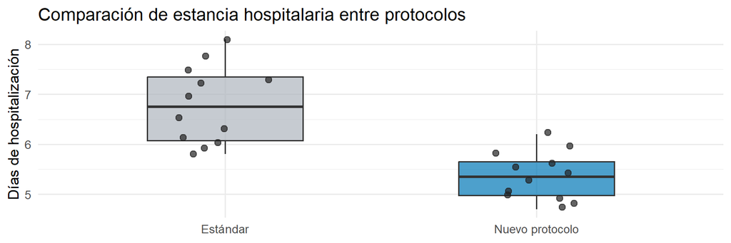

## Prueba t para muestras pareadas

Compara medias de dos mediciones en los mismos sujetos (antes-después, lado derecho-izquierdo, etc.).

Se define $D_i = X_{1i} - X_{2i}$.

$$H_0: \mu_D = 0 \quad vs \quad H_a: \mu_D \neq 0$$

**Estadístico de prueba:**

$$\boxed{t = \frac{\bar{d}}{s_d/\sqrt{n}}} \sim t(n-1) \text{ bajo } H_0$$

**Ventaja:** Elimina la variabilidad inter-sujeto, aumentando la potencia.

## Prueba t para muestras pareadas

**Ejemplo:** ROM de rodilla (°) antes y después de 10 sesiones de fisioterapia en 8 pacientes.

| Paciente | Antes | Después | $D_i$ |
| --- | --- | --- | --- |
| 1 | 85 | 105 | 20 |
| 2 | 92 | 118 | 26 |
| 3 | 78 | 98 | 20 |
| 4 | 110 | 125 | 15 |
| 5 | 95 | 120 | 25 |
| 6 | 80 | 100 | 20 |
| 7 | 88 | 112 | 24 |
| 8 | 100 | 122 | 22 |

$gl=7$; $p < 0.001$ **→ Mejora significativa.**

## Código R: muestras pareadas

```r
antes   <- c(85, 92, 78, 110, 95, 80, 88, 100)
despues <- c(105,118, 98, 125,120,100,112, 122)
t.test(despues, antes, paired = TRUE, alternative = "two.sided")
```

```
    Paired t-test

data:  despues and antes
t = 17.151, df = 7, p-value = 5.623e-07
alternative hypothesis: true mean difference is not equal to 0
95 percent confidence interval:
 18.53579 24.46421
sample estimates:
mean difference
           21.5
```

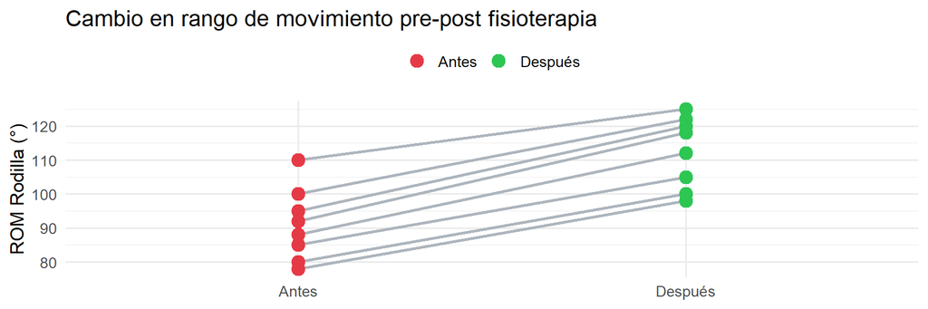

# ANÁLISIS DE VARIANZAS

## Prueba para una varianza

Contrasta si la varianza poblacional es igual a un valor $\sigma_0^2$.

$$H_0: \sigma^2 = \sigma_0^2 \quad vs \quad H_a: \sigma^2 \neq \sigma_0^2$$

**Estadístico de prueba:**

$$\boxed{\chi^2 = \frac{(n-1)s^2}{\sigma_0^2}} \sim \chi^2_{(n-1)} \text{ bajo } H_0$$

Requiere normalidad de los datos.

**IC al $(1-\alpha)$% para $\sigma^2$:**

$$\left(\frac{(n-1)s^2}{\chi^2_{\alpha/2,n-1}},\; \frac{(n-1)s^2}{\chi^2_{1-\alpha/2,n-1}}\right)$$

## Prueba para una varianza

**Ejemplo:** Un glucómetro de referencia tiene $\sigma^2_0 = 9$ (mg/dL)². En 15 mediciones del nuevo equipo se obtuvo $s^2 = 14.2$.

$H_0: \sigma^2 = 9$ vs $H_a: \sigma^2 \neq 9$

$$\chi^2 = \frac{14 \times 14.2}{9} = 22.09$$

$gl = 14; \quad \chi^2_{0.025,14}=5.629; \quad \chi^2_{0.975,14}=26.12$

No hay evidencia de que la variabilidad del nuevo equipo difiera de la referencia.

## Prueba F para dos varianzas

Compara varianzas de dos grupos independientes.

$$H_0: \sigma_1^2 = \sigma_2^2 \quad vs \quad H_a: \sigma_1^2 \neq \sigma_2^2$$

**Estadístico de prueba:**

$$\boxed{F = \frac{S_1^2}{S_2^2}} \sim F(n_1-1,\; n_2-1) \text{ bajo } H_0$$

**Usos prácticos:**

- Verificar el supuesto de homocedasticidad antes del t-test
- Comparar precisión de dos instrumentos de medición
- Comparar variabilidad entre grupos de pacientes

## Prueba F para dos varianzas

**Ejemplo:** Se compara la variabilidad de la saturación de oxígeno ($SpO_2$, %) entre pacientes con EPOC leve ($n_1=20$, $s_1^2=4.8$) y EPOC severo ($n_2=18$, $s_2^2=10.3$).

$H_0: \sigma_1^2 = \sigma_2^2$ vs $H_a: \sigma_1^2 \neq \sigma_2^2$

$$F = \frac{10.3}{4.8} = 2.146$$

$gl_1=17, \quad gl_2=19; \quad F_{0.025,17,19}=2.83$

```r
var.test(rnorm(20,95,sqrt(4.8)),
         rnorm(18,91,sqrt(10.3)))$p.value |>
  round(4)
```

```
[1] 0.8552
```

# ANOVA DE UN FACTOR

## Concepto y estructura

El **Análisis de Varianza (ANOVA) de un factor** extiende el t-test a **$k \geq 3$ grupos**.

$$H_0: \mu_1 = \mu_2 = \cdots = \mu_k$$
$$H_a: \text{al menos dos medias son distintas}$$

**Descomposición de la variabilidad total:**

$$\underbrace{SCT}_{\text{Total}} = \underbrace{SCTr}_{\text{Entre grupos}} + \underbrace{SCE}_{\text{Dentro grupos}}$$

$$SCTr = \sum_{i=1}^k n_i(\bar{x}_i - \bar{x})^2$$

$$SCE = \sum_{i=1}^k\sum_{j=1}^{n_i}(x_{ij}-\bar{x}_i)^2$$

## Tabla de ANOVA

| Fuente | SC | gl | CM | F |
| --- | --- | --- | --- | --- |
| Entre grupos | $SCTr$ | $k-1$ | $CMTr$ | $CMTr/CME$ |
| Dentro grupos | $SCE$ | $N-k$ | $CME$ |  |
| Total | $SCT$ | $N-1$ |  |  |

$$F = \frac{CMTr}{CME} \sim F_{(k-1, N-k)} \text{ bajo } H_0$$

**Supuestos:**

- Normalidad dentro de cada grupo
- Homocedasticidad: $\sigma_1^2 = \sigma_2^2 = \cdots = \sigma_k^2$
- Independencia de las observaciones

## Ejemplo: Tratamiento para lumbalgia crónica

**Contexto:** 45 pacientes con lumbalgia crónica asignados aleatoriamente a 3 grupos ($n=15$ c/u). Se midió el dolor EVA (0–10) a las 8 semanas.

|  | Tto A | Tto B | Tto C |
| --- | --- | --- | --- |
| $\bar{x}_i$ | 4.2 | 6.1 | 5.0 |
| $s_i$ | 1.3 | 1.5 | 1.4 |

$\bar{x} = (4.2+6.1+5.0)/3 = 5.1$

$SCTr = 15[(4.2-5.1)^2+(6.1-5.1)^2+(5.0-5.1)^2]$ $= 15[0.81+1.00+0.01] = \mathbf{27.3}$

$F_{0.05, 2, 42} = 3.22$ **→ Rechazar $H_0$**

## Código R

```r
set.seed(2024)
dolor <- c(rnorm(15,4.2,1.3), rnorm(15,6.1,1.5), rnorm(15,5.0,1.4))
grupo <- factor(rep(c("Tto A","Tto B","Tto C"), each=15))
modelo <- aov(dolor ~ grupo)
summary(modelo)
```

```
            Df Sum Sq Mean Sq F value Pr(>F)
grupo        2  18.71   9.356   4.137 0.0229 *
Residuals   42  94.99   2.262
---
Signif. codes:  0 '***' 0.001 '**' 0.01 '*' 0.05 '.' 0.1 ' ' 1
```

## Prueba post-hoc de Tukey

Cuando ANOVA rechaza $H_0$, la prueba **post-hoc de Tukey HSD** identifica qué pares de grupos difieren significativamente, controlando la tasa de error global.

```r
TukeyHSD(modelo)
```

```
  Tukey multiple comparisons of means
    95% family-wise confidence level

Fit: aov(formula = dolor ~ grupo)

$grupo
                  diff        lwr       upr     p adj
Tto B-Tto A  1.5781122  0.2439749 2.9122496 0.0170778
Tto C-Tto A  0.8478365 -0.4863009 2.1819738 0.2811765
Tto C-Tto B -0.7302757 -2.0644131 0.6038616 0.3868729
```

[figure not shown]

## Verificación de supuestos ANOVA

```r
# Normalidad (Shapiro-Wilk por grupo)
tapply(dolor, grupo, shapiro.test)
```

```
$`Tto A`

    Shapiro-Wilk normality test

data:  X[[i]]
W = 0.88828, p-value = 0.06317


$`Tto B`

    Shapiro-Wilk normality test

data:  X[[i]]
W = 0.91469, p-value = 0.1598


$`Tto C`

    Shapiro-Wilk normality test

data:  X[[i]]
W = 0.95297, p-value = 0.5724
```

```r
# Homocedasticidad (Levene o Bartlett)
bartlett.test(dolor ~ grupo)
```

```
    Bartlett test of homogeneity of variances

data:  dolor by grupo
Bartlett's K-squared = 1.0043, df = 2, p-value = 0.6052
```

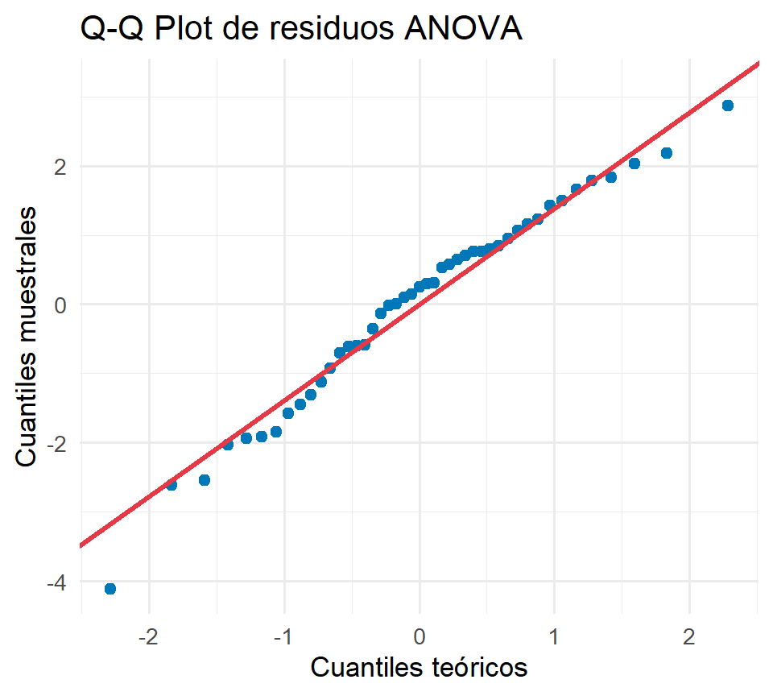

**Note**

Si los supuestos de normalidad u homocedasticidad no se cumplen, use la prueba no paramétrica de **Kruskal-Wallis** como alternativa al ANOVA de un factor.

## Resumen: ¿Qué prueba usar?

| Objetivo | Variables | Prueba | R |
| --- | --- | --- | --- |
| Asociación | 2 categóricas | $\chi^2$ de independencia | `chisq.test()` |
| Una proporción | Categórica | Prueba Z / binomial | `prop.test()` |
| Dos proporciones | Categórica | Prueba Z | `prop.test()` |
| Una media | Cuantitativa | Prueba t (una muestra) | `t.test(mu=...)` |
| Dos medias independientes | Cuantitativa + grupo | Prueba t (Welch/pooled) | `t.test(..., paired=FALSE)` |
| Dos medias pareadas | Cuantitativa | Prueba t pareada | `t.test(..., paired=TRUE)` |
| Una varianza | Cuantitativa | Prueba $\chi^2$ | Cálculo directo |
| Dos varianzas | Cuantitativa + grupo | Prueba F | `var.test()` |
| $k \geq 3$ medias | Cuantitativa + grupo | ANOVA de un factor | `aov()` + `TukeyHSD()` |

**Tip**

**Flujo de decisión:** (1) ¿Cuántos grupos? → (2) ¿Tipo de variable respuesta? → (3) ¿Muestras independientes o pareadas? → (4) ¿Se cumplen los supuestos paramétricos?

## Infografía: Pruebas sobre medias

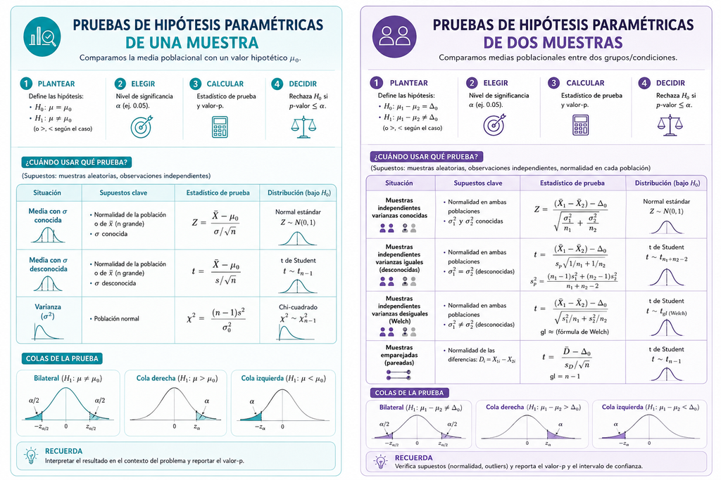

## Infografía: Pruebas sobre proporciones y varianzas

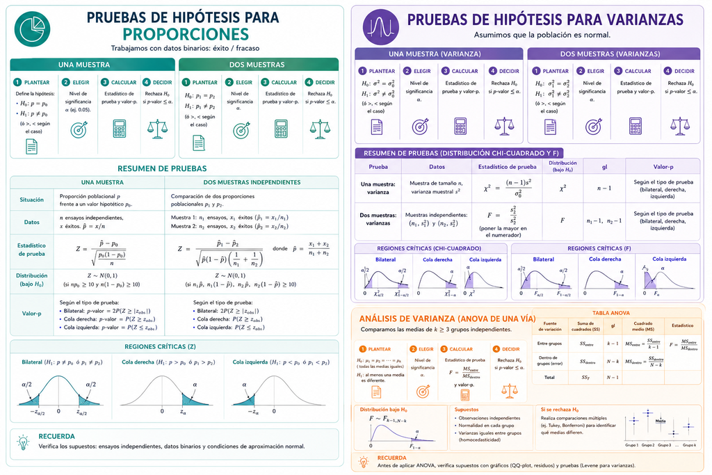

# GRACIAS!

# Citación y derechos de autor

Este material ha sido creado por [Giovany Babativa-Márquez](https://github.com/jgbabativam) y es de libre distribución bajo la licencia [Creative Commons Attribution-ShareAlike 4.0](https://creativecommons.org/licenses/by-sa/4.0/).

Cualquier copia parcial o total de este material, debe citar la fuente como:

> Babativa-Márquez, J.G. *Diapositivas del curso de Estadística Fundamental para Ciencias de la Salud*. URL: https://jgbabativam.github.io/EstadFundSalud/